# Assignment 03 - Text Mining

Author

Jazmin Hernandez

### 1.

Before removing the stopwords, the number of each token is as expected with most words being snowball stopwords. However, after removing stopwords, tokens such as covid, 19, patients and cancer appear most often which is more appropriate given the articles being from PubMed searches. The five most common tokens for each search term are as follows:

- COVID: covid
- Cystic fibrosis: fibrosis
- Meningitis: patients
- Preeclampsia: pre
- Prostate cancer: cancer

```r
library(dplyr)
abstracts |>
  unnest_tokens(token, abstract) |>
  count(token, sort = TRUE)
```

```
# A tibble: 20,561 × 2
   token     n
   <chr> <int>
 1 the   28126
 2 of    24760
 3 and   19993
 4 in    14653
 5 to    10920
 6 a      8245
 7 with   8038
 8 covid  7275
 9 19     7080
10 is     5649
# ℹ 20,551 more rows
```

```r
# Removing stopwords
abstracts |>
  unnest_tokens(token, abstract) |>
  anti_join(stop_words, by = c("token" = "word")) |>
  count(token, sort = TRUE)
```

```
# A tibble: 19,972 × 2
   token            n
   <chr>        <int>
 1 covid         7275
 2 19            7080
 3 patients      4674
 4 cancer        3999
 5 prostate      3832
 6 disease       2574
 7 pre           2165
 8 eclampsia     2005
 9 preeclampsia  1863
10 treatment     1841
# ℹ 19,962 more rows
```

```r
abstracts |>
  unnest_tokens(token, abstract) |>
  anti_join(stop_words, by = c("token" = "word")) |>
  group_by(term) |>
  count(token, sort = TRUE) |>
  slice_head(n = 5)
```

```
# A tibble: 25 × 3
# Groups:   term [5]
   term            token        n
   <chr>           <chr>    <int>
 1 covid           covid     7275
 2 covid           19        7035
 3 covid           patients  2293
 4 covid           disease    943
 5 covid           pandemic   800
 6 cystic fibrosis fibrosis   867
 7 cystic fibrosis cystic     862
 8 cystic fibrosis cf         625
 9 cystic fibrosis patients   586
10 cystic fibrosis disease    400
# ℹ 15 more rows
```

### 2.

```r
top10_bigrams <- abstracts |>
  unnest_tokens(bigram, abstract, token = "ngrams", n = 2) |>
  count(bigram, sort = TRUE) |>
  slice_head(n = 10)
top10_bigrams
```

```
# A tibble: 10 × 2
   bigram              n
   <chr>           <int>
 1 covid 19         6969
 2 of the           3883
 3 in the           3418
 4 prostate cancer  3222
 5 pre eclampsia    1854
 6 patients with    1587
 7 of covid         1519
 8 and the          1154
 9 to the           1061
10 of prostate       870
```

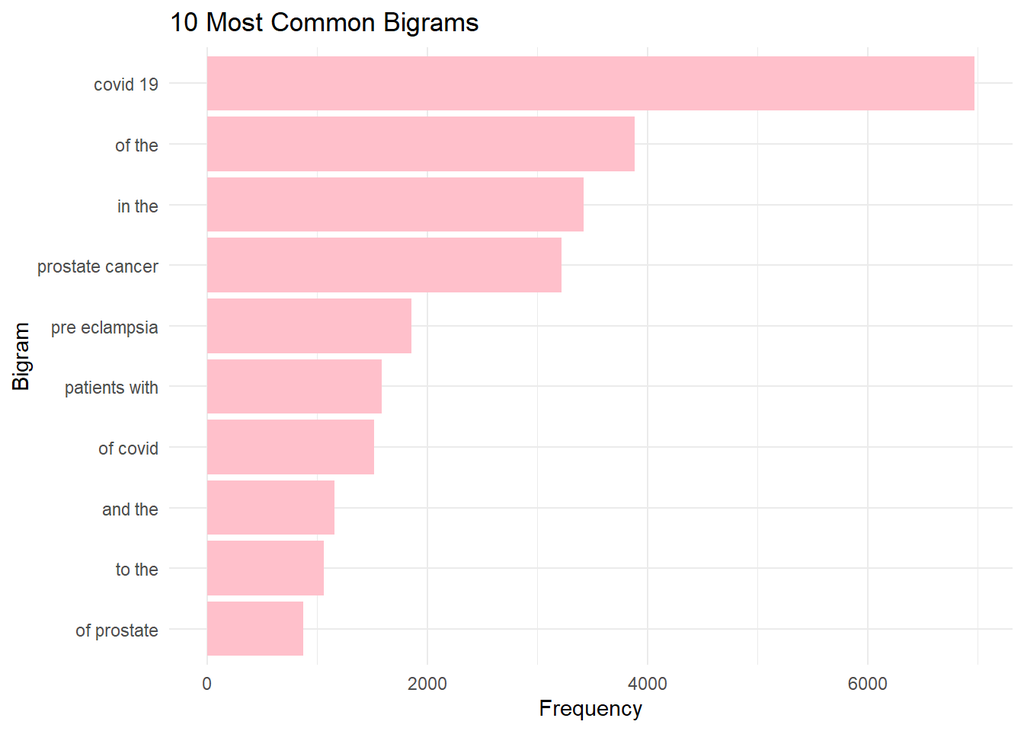

```r
library(ggplot2)
top10_bigrams |>
  ggplot(aes(x = reorder(bigram, n), y = n)) +   # Reorder bigrams based on frequency
  geom_bar(stat = "identity", fill = "pink") + # Create a bar chart
  labs(x = "Bigram", y = "Frequency", title = "10 Most Common Bigrams") +
  coord_flip() +   # Flip the coordinates for better readability
  theme_minimal()  # Use a minimal theme
```

### 3.

The 5 tokens from each search term with the highest TF-IDF value are:

- COVID: covid, pandemic, coronavirus, sars, cov
- Cystic Fibrosis: cf, fibrosis, cystic, cftr, sweat
- Meningitis: meningitis, meningeal, pachymeningitis, csf, meninges
- Preeclampsia: eclampsia, preeclampsia, pregnancy, maternal, gestational
- Prostate Cancer: prostate, androgen, psa, prostatectomy, castration

In question 1, we were counting the number of tokens across the entire dataset which resulted in the words being more snowball stopwords. However, for this question we are focused on words that are specific to each of the search terms. The higher the tf_idf score the more relevant it is to the specific document or search term.

```r
abstracts|>
  unnest_tokens(word, abstract) |>
  count(term, word, sort = TRUE) |>
  bind_tf_idf(word, term, n) |>
  group_by(term) |>
  slice_max(tf_idf, n = 5) |>
  ungroup()
```

```
# A tibble: 25 × 6
   term            word            n      tf   idf  tf_idf
   <chr>           <chr>       <int>   <dbl> <dbl>   <dbl>
 1 covid           covid        7275 0.0371  1.61  0.0597
 2 covid           pandemic      800 0.00408 1.61  0.00657
 3 covid           coronavirus   647 0.00330 1.61  0.00531
 4 covid           sars          372 0.00190 1.61  0.00305
 5 covid           cov           334 0.00170 1.61  0.00274
 6 cystic fibrosis cf            625 0.0127  0.916 0.0117
 7 cystic fibrosis fibrosis      867 0.0176  0.511 0.00901
 8 cystic fibrosis cystic        862 0.0175  0.511 0.00896
 9 cystic fibrosis cftr           86 0.00175 1.61  0.00282
10 cystic fibrosis sweat          83 0.00169 1.61  0.00272
# ℹ 15 more rows
```

## Sentiment Analysis

### 1.

The most common sentiments for each search term include:

- COVID: positive
- Prostate Cancer: negative
- Preeclampsia: positive
- Cystic Fibrosis: positive
- Meningitis: negative

After removing positive and negative from the list we are left with

- COVID: fear
- Prostate Cancer: fear
- Preeclampsia: anticipation
- Cystic Fibrosis: disgust
- Meningitis: fear

```r
library(textdata)
abstracts |>
  unnest_tokens(word, abstract) |>
  inner_join(get_sentiments("nrc"), by = "word", relationship = "many-to-many") |>
  count(term, sentiment, sort = TRUE)
```

```
# A tibble: 50 × 3
   term            sentiment     n
   <chr>           <chr>     <int>
 1 covid           positive   9874
 2 covid           negative   9452
 3 prostate cancer negative   8918
 4 prostate cancer fear       8118
 5 preeclampsia    positive   8014
 6 covid           fear       7730
 7 prostate cancer positive   7121
 8 preeclampsia    negative   7032
 9 prostate cancer sadness    6345
10 covid           trust      5897
# ℹ 40 more rows
```

```r
# removing positive and negative from list
nrc_fun <- get_sentiments("nrc")
nrc_fun <- nrc_fun[!nrc_fun$sentiment %in% c("positive","negative"), ]
abstracts |>
  unnest_tokens(word, abstract) |>
  inner_join(nrc_fun, by = "word", relationship = "many-to-many") |>
  group_by(term) |>
  summarise(sentiment = names(which.max(table(sentiment))))
```

```
# A tibble: 5 × 2
  term            sentiment
  <chr>           <chr>
1 covid           fear
2 cystic fibrosis disgust
3 meningitis      fear
4 preeclampsia    anticipation
5 prostate cancer fear
```

### 2.

Prostate cancer appears to have a lower variability in sentiment as seen in the lower spread of the score compared to the other search terms. Cystic fibrosis seems to have a slightly more positive spread of sentiment scores compared to the other search terms.

```r
abstracts <- abstracts|>
  mutate(abstract_id = row_number())
```

```r
afinn <- get_sentiments("afinn")
data_affin <- abstracts |>
  unnest_tokens(word, abstract) |>
  inner_join(afinn, by = "word") |>

  group_by(abstract_id, term) |>
  summarise(avg_score = mean(value, na.rm = TRUE), .groups = "drop")
head(data_affin)
```

```
# A tibble: 6 × 3
  abstract_id term  avg_score
        <int> <chr>     <dbl>
1           1 covid    -1.13
2           2 covid    -2
3           3 covid     0.214
4           4 covid    -0.8
5           5 covid    -1.67
6           6 covid    -0.143
```

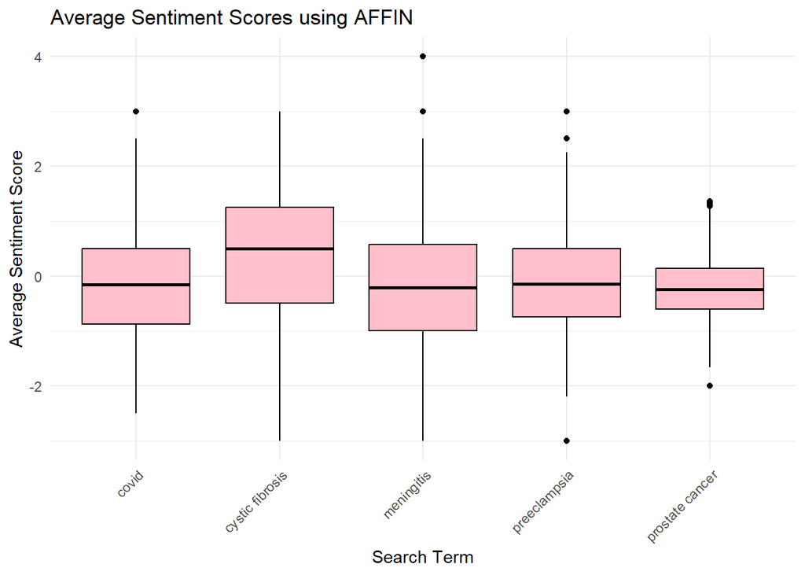

```r
# Creating visualization
ggplot(data_affin, aes(x = term, y = avg_score)) +
  geom_boxplot(fill = "pink", color = "black") +
  theme_minimal() +
  labs(title = "Average Sentiment Scores using AFFIN",
       x = "Search Term",
       y = "Average Sentiment Score") +
  theme(axis.text.x = element_text(angle = 45, hjust = 1))
```